# Final Project–Predict Opioid Overdose Events in Cincinnati

Ziyi Yang & Xiaoyi Wu

12/2/2021

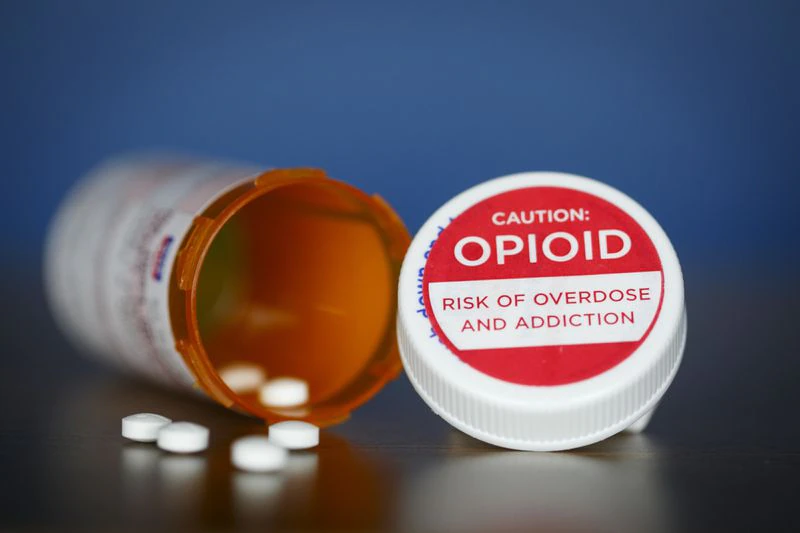

## I. Introduction– Motivation

Drug overdose deaths in the United States quadrupled between 1999 and 2017, then reversed slightly in 2018. Two-thirds of drug overdose deaths involve opioids (prescription opioids, heroin and illegal fentanyl). Ways to reduce overdoses include safer prescribing, expanded treatment for people with opioid use disorder (OUD), and harm reduction programs (e.g., naloxone distribution). [In the summer of 2016](https://www.washingtonpost.com/news/morning-mix/wp/2016/08/29/this-is-unprecedented-174-heroin-overdoses-in-6-days-in-cincinnati/), Cincinnati experienced an unprecedented instantaneous heroin overdose. Cincinnati firefighters have responded to nearly 1600 overdose emergencies over the year. “This is an epidemic in our community that must be addressed. We are working with the State of Ohio and local partners to tackle this crisis,” [said Mayor John Cranley](https://www.cincinnati-oh.gov/mayor/news/cincinnati-heroin-epidemic-mayor-cranley-councilmember-sittenfeld-announce-initiatives-to-combat-opioid-overdoses/).Each needs a strategy to identify high-need populations, but officer often operate without a comprehensive understanding of the risks associated with the entire community. In this project, we will estimate a geospatial risk prediction model, predicting overdoses as a function of environmental factors.

**Use Case**: * Display occurred overdose case detailed information * Show spatial distribution around fire stations * Equipping officers with opioid overdose antidote naloxone

It can help the local government especially for Cincinnati Fire Department to allocate their resources more efficiently. By analyzing the actual overdose location and risk factors, CFD staff can have a sense about which areas/quarter mile within a engine have a higher density of overdose cases that might need to more services and interventions in that area or equipping officers with the opioid overdose antidote naloxone. Additional focus on overdose-incidence areas and funding extensive community outreach efforts to educate individuals on how to recognize opioid overdoses and take immediate life-saving measures.

## II. Setup and Data Loading

### 2.1 Setup

In this section, we loaded necessary libraries, created plot theme options and map theme options, and identified functions of quintile breaks, and average nearest neighbor distance for further analysis.

```r
# 1. load Libraries
library(sf)
library(tidyverse)
library(mapview)
library(spdep)
library(caret)
library(ckanr)
library(FNN)
library(grid)
library(gridExtra)
library(ggcorrplot)
library(jtools)
library(stargazer)
library(broom)
library(tufte)
library(rmarkdown)
library(kableExtra)
library(tidycensus)
library(RSocrata)
library(viridis)
library(spatstat)
library(raster)
library(knitr)
library(rgdal)
library(kableExtra)

root.dir = "https://raw.githubusercontent.com/urbanSpatial/Public-Policy-Analytics-Landing/master/DATA/"
source("https://raw.githubusercontent.com/urbanSpatial/Public-Policy-Analytics-Landing/master/functions.r")
palette5 <- c("#f0f9e8","#bae4bc","#7bccc4","#43a2ca","#0868ac")
```

### 2.2 Data Preparation

- [**Cincinnati Boundary**](https://data-cagisportal.opendata.arcgis.com/datasets/cincinnati-city-boundary/explore): A base and outline of the City of Cincinnati. https://opendata.arcgis.com/datasets/ed78f4754b044ac5815d0a9efe9bb336_1.geojson
- [**Cincinnati Neighborhoods**](https://data-cagisportal.opendata.arcgis.com/datasets/cincinnati-community-council-boundaries/explore): A base and outline of the neighborhoods of Cincinnati. https://opendata.arcgis.com/datasets/fff393f0112544b397838f9cf4d7765a_1.geojson
- [**FireHouse**](https://data.cincinnati-oh.gov/Safety/Hamilton-County-Firehouse-Locations/ukeu-h8z6): Geojson file contains all firehouses location in Hamilton County. https://opendata.arcgis.com/datasets/a6f043d181f94e37a274975a3718b7af_16.geojson

**Opioid Overdose Data**: This analysis focuses on opioid overdose cases in Cincinnati.

- [**Opioid Overdose**](https://github.com/sydng/Cincinatti_Overdose_Data): This repository hosts a now deprecated version of EMS data for opioid overdose dispatches for Cincinnati, OH with xy coordinates. Data for July 2015 through November 2017 is included.

**Risk Factors Data**: This analysis selects six point level features that may intrigue opioid cases to build the model. These datasets can be found from Cincinnati 311 (Non-Emergency) Service Requests. (https://data.cincinnati-oh.gov/Thriving-Neighborhoods/Cincinnati-311-Non-Emergency-Service-Requests/4cjh-bm8b)

- [**Abandon Cars**] * [**Dead Animals**] * [**Graffiti**] * [**Trash**] * [**Streets needed Cleaning**] * [**Pothole**]

```r
cinPD <-
  st_read("https://opendata.arcgis.com/datasets/9bc1afaff72e4f44a6d19280c159c951_4.geojson") %>%
  st_transform('ESRI:102258')

cinBoundary <-
  st_read("https://opendata.arcgis.com/datasets/ed78f4754b044ac5815d0a9efe9bb336_1.geojson") %>%
  st_transform('ESRI:102258')

firestation <- st_read("https://opendata.arcgis.com/datasets/a6f043d181f94e37a274975a3718b7af_16.geojson") %>%
  filter(BND_NAME == "CINCINNATI")%>%
  st_transform(st_crs(cinBoundary))

#2016 Opioid Overdose Data
opioid <-
  st_read("Cinci_Overdoses.geojson") %>%
  filter(grepl(2016,CREATE_TIM)) %>%
  st_transform('ESRI:102258')

opioid17 <-
  st_read("Cinci_Overdoses.geojson") %>%
  filter(grepl(2017,CREATE_TIM)) %>%
  st_transform('ESRI:102258')

# Creating a fishnet grid
cin_fishnet <-
  st_make_grid(cinBoundary,
               cellsize = 500,
               square = TRUE) %>%
  .[cinBoundary] %>%
  st_sf() %>%
  mutate(uniqueID = rownames(.))

cinNeigh <-
  st_read("https://opendata.arcgis.com/datasets/fff393f0112544b397838f9cf4d7765a_1.geojson") %>%
  st_transform('ESRI:102258') %>%
  st_transform(st_crs(cin_fishnet))

# import risk factors
request_311 <-
  st_read("Cincinnati_311__Non-Emergency__Service_Requests.csv") %>%
  filter(grepl(2016,REQUESTED_DATE))

dead_animals <- request_311%>%
  filter(grepl("DAPUB1",SERVICE_CODE))%>%
  dplyr::select(Y = LATITUDE, X = LONGITUDE) %>%
  st_as_sf(coords = c("X", "Y"), crs = 4326, agr = "constant") %>%
  st_transform('ESRI:102258') %>%
  st_transform(st_crs(cin_fishnet))%>%
  mutate(Legend = "dead_animals")

abandon_cars <- request_311%>%
  filter(grepl("ABAN-VPR", SERVICE_CODE))%>%
  dplyr::select(Y = LATITUDE, X = LONGITUDE) %>%
  st_as_sf(coords = c("X", "Y"), crs = 4326, agr = "constant") %>%
  st_transform('ESRI:102258') %>%
  st_transform(st_crs(cin_fishnet))%>%
  mutate(Legend = "abandon_cars")

pothole <- request_311%>%
  filter(grepl("PTHOLE",SERVICE_CODE))%>%
  dplyr::select(Y = LATITUDE, X = LONGITUDE) %>%
  st_as_sf(coords = c("X", "Y"), crs = 4326, agr = "constant") %>%
  st_transform('ESRI:102258') %>%
  st_transform(st_crs(cin_fishnet))%>%
  mutate(Legend = "pothole")

trash <- request_311%>%
  filter(grepl("RF-COLLT",SERVICE_CODE) |grepl("TRASH-I",SERVICE_CODE))%>%
  dplyr::select(Y = LATITUDE, X = LONGITUDE) %>%
  st_as_sf(coords = c("X", "Y"), crs = 4326, agr = "constant") %>%
  st_transform('ESRI:102258') %>%
  st_transform(st_crs(cin_fishnet))%>%
  mutate(Legend = "trash")

graffiti <- request_311%>%
  filter(grepl("GRFITI",SERVICE_CODE))%>%
  dplyr::select(Y = LATITUDE, X = LONGITUDE) %>%
  st_as_sf(coords = c("X", "Y"), crs = 4326, agr = "constant") %>%
  st_transform('ESRI:102258') %>%
  st_transform(st_crs(cin_fishnet))%>%
  mutate(Legend = "graffiti")

street_cleaning <- request_311%>%
  filter(grepl("SCLEN1",SERVICE_CODE))%>%
  dplyr::select(Y = LATITUDE, X = LONGITUDE) %>%
  st_as_sf(coords = c("X", "Y"), crs = 4326, agr = "constant") %>%
  st_transform('ESRI:102258') %>%
  st_transform(st_crs(cin_fishnet))%>%
  mutate(Legend = "street_cleaning")

# Census data
# View(load_variables(2018,'acs5',cache = TRUE))
tracts16 <-
  get_acs(geography = "tract", variables = c("B00001_001E","B02001_002E","B19013_001E","B25002_001E","B06012_002E","B27011_008E"),
          year=2016, state="OH", county="Hamilton", geometry=T, output="wide") %>%
  st_transform('ESRI:102258') %>%
  rename(TotalPop = B00001_001E,
         Whites = B02001_002E,
         MedHHInc = B19013_001E,
         TotalUnit = B25002_001E,
         TotalPoverty = B06012_002E,
         TotalUnemployment =    B27011_008E) %>%
dplyr::select(-NAME, -starts_with("B")) %>% #-starts_with("B") awesome!
  mutate(pctWhite = ifelse(TotalPop > 0, Whites / TotalPop * 100,0),
         pctPoverty = ifelse(TotalPop > 0, TotalPoverty / TotalPop *100, 0),
         pctUnemploy = ifelse(TotalPop > 0, TotalUnemployment / TotalPop *100, 0)
         ) %>%
  dplyr::select(-Whites, -TotalPoverty ,-TotalUnemployment,-GEOID) %>%
  st_transform(st_crs(cin_fishnet))

tracts16.MedHHInc <- tracts16 %>%
  dplyr::select(MedHHInc) %>%
  rename(Legend = MedHHInc)
tracts16.pctWhite <- tracts16 %>%
  dplyr::select(pctWhite)%>%
  rename(Legend = pctWhite)
tracts16.pctPoverty <- tracts16 %>%
  dplyr::select(pctPoverty)%>%
  rename(Legend = pctPoverty)
tracts16.pctUnemploy <- tracts16 %>%
  dplyr::select(pctUnemploy)%>%
  rename(Legend = pctUnemploy)
```

## III. Visualizaion and Analysis

*METHOD* This analysis uses open sourced data from the City of Cincinnati’s Open Data Portal. Using a fishnet grid, I break the city into square cells to design a model which predicts the risk of opioid overdose cases occurrence in each cell based on its risk factor data.

### 3.1 Exploratory Analysis

#### 3.1.1 A map of opioid overdose events in 2016, Cincinnati

Figure 1.1 and 1.2 below show the distribution of Cincinnati opioid overdose events in 2016. We can see from the below map that there are two distinct hotspots area. The overdose events concentrated in the south and west of the city.

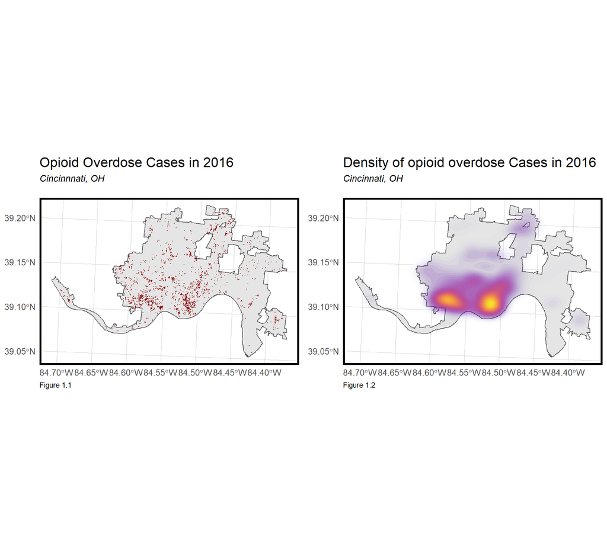

```r
# 1. A map of opioid overdose cases in 2016, Cincinnati
grid.arrange(ncol=2,
             ggplot() +
               geom_sf(data = cinBoundary) +
               geom_sf(data = opioid, colour="darkred", size=0.1, show.legend = "point") +
               labs(title= "Opioid Overdose Cases in 2016",
                    subtitle = 'Cincinnnati, OH\n',
                    caption = 'Figure 1.1') +
               mapTheme() +
               plotTheme(),

             ggplot() +
               geom_sf(data = cinBoundary, fill = "#E5E5E5") +
               stat_density2d(data = data.frame(st_coordinates(opioid)),
                              aes(X, Y, fill = ..level.., alpha = ..level..),
                              size = 0.01, bins = 40, geom = 'polygon') +
               scale_fill_viridis_c(option = "plasma") +
               scale_alpha(range = c(0.00, 0.35), guide = FALSE) +
               labs(title = "Density of opioid overdose Cases in 2016",
                    subtitle = 'Cincinnati, OH\n',
                    caption = 'Figure 1.2') +
               mapTheme() +
               theme(legend.position = "none") +
               plotTheme())
```

Figure 2 presents the opioid events in a fishnet which is the basic scale this analysis mainly works at.

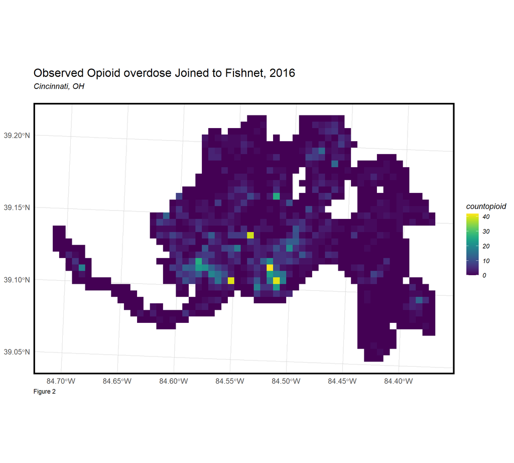

```r
# Aggregate points to the fishnet
opioid_net <-
  dplyr::select(opioid) %>%
  mutate(countopioid = 1) %>%
  aggregate(., cin_fishnet, sum) %>%
  mutate(countopioid = replace_na(countopioid, 0),
         uniqueID = rownames(.),
         cvID = sample(round(nrow(cin_fishnet) / 24),
                       size=nrow(cin_fishnet), replace = TRUE))
ggplot() +
  geom_sf(data = opioid_net, aes(fill = countopioid), color = NA) +
  scale_fill_viridis() +
  labs(title = "Observed Opioid overdose Joined to Fishnet, 2016",
       subtitle = 'Cincinnati, OH\n',
       caption = 'Figure 2') +
  mapTheme() +
  plotTheme()
```

#### 3.1.3 A Bar Chart of Opioid Incidents within 1/4-Mile of Each Fire Station

The Cincinnati Fire Department operate 26 fire stations throughout the city neighborhoods of Cincinnati. As we can see from the bar chart below, the number of overdoses occurring within a quarter mile of each site varies significantly. Some sites experienced quite a few overdoses within a quarter mile, while others had almost no overdoses within a quarter mile. In south of the city, Engine 03, Engine 05 had more than 200 overdoses within a quarter mile in 2016. Engine 08, Engine37 experienced fewer than 20 overdoses within a quarter mile. This metric tells us which sites might need additional resources.

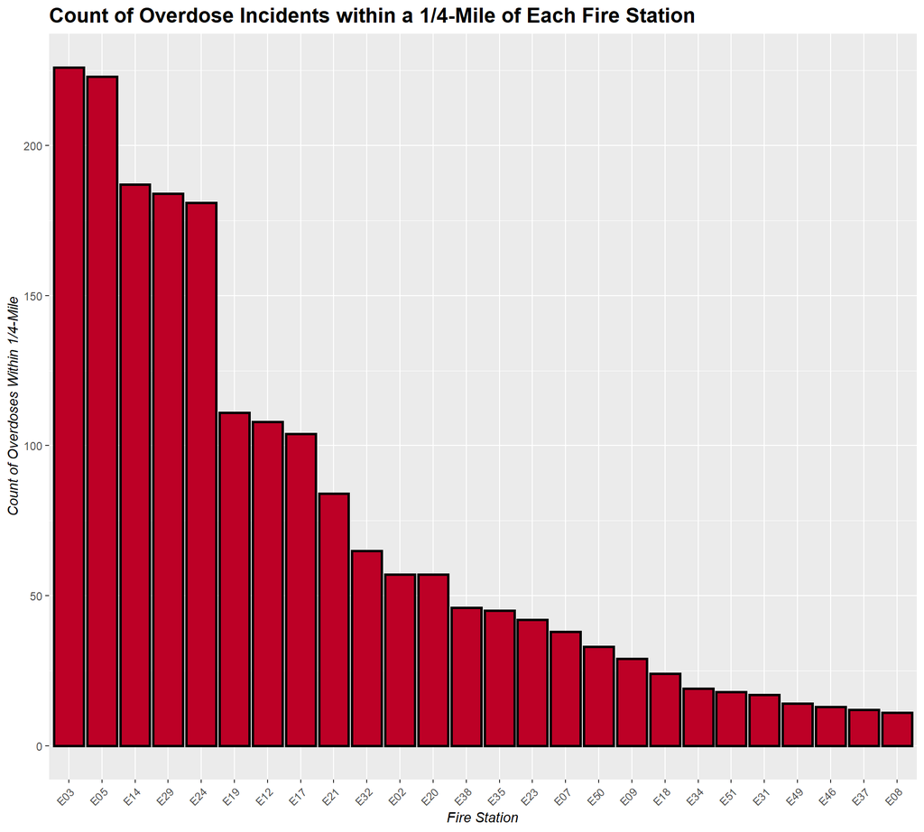

```r
stationsBuffer_QtrMi <-
  st_buffer(firestation, 1320)

#determine the count of overdoses within 1/4-mile of each fire station
DoseCentroids <-
  st_centroid(opioid) %>%
  mutate(counter = 1) %>%
  dplyr::select(counter)

buffersAndDose <-
  aggregate(DoseCentroids, stationsBuffer_QtrMi, sum) %>%
  cbind(stationsBuffer_QtrMi) %>%
  mutate(counter = replace_na(counter, 0),
         Area = as.numeric(st_area(.)))

summarizeFire <-
  buffersAndDose %>%
  group_by(ENGINE) %>%
  summarize(Building_Count = sum(counter))


#plot the data in a bar chart
ggplot(data = buffersAndDose, aes(x = reorder(ENGINE,-counter), y = counter, fill = "#BD0026")) +
  geom_bar(stat = "identity", color = "black", size = 1) +
  scale_fill_manual(values = c("#BD0026")) +
  labs(title = "Count of Overdose Incidents within a 1/4-Mile of Each Fire Station",
       x = "Fire Station", y = "Count of Overdoses Within 1/4-Mile") +
  theme(legend.position = "none", axis.text.x = element_text(angle = 45, hjust = 1),
        plot.title = element_text(face = "bold", size = 16), axis.title = element_text(face = "italic"))
```

#### 3.1.4 A map of Overdose Incidents within 1/4-Mile of Each Fire Station

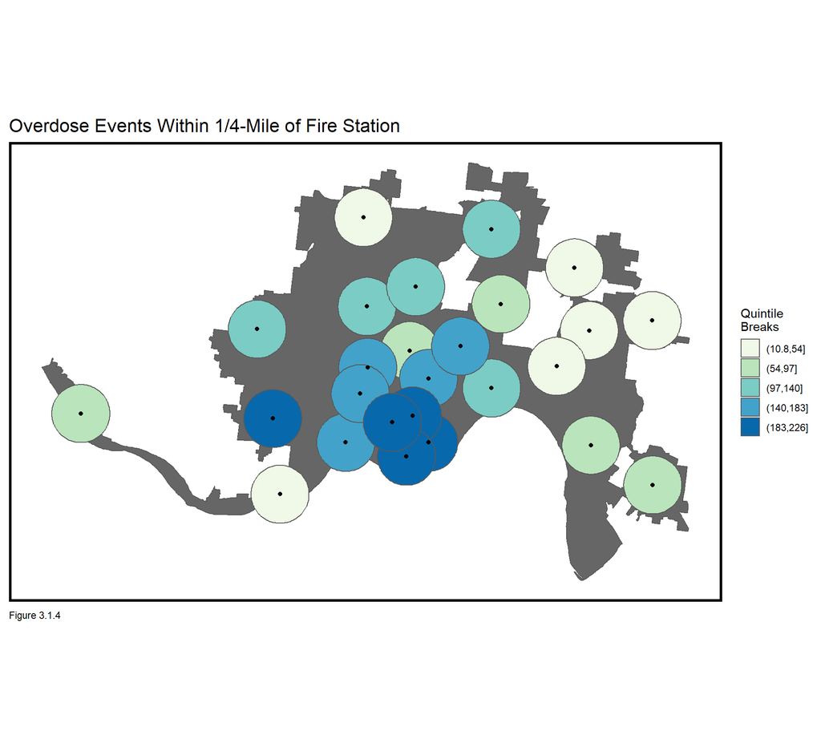

```r
data_cuts <- cut(summarizeFire$Building_Count, 5)
ggplot() +
  geom_sf(data = cinBoundary, fill = "grey40") +
  geom_sf(data = summarizeFire, aes(fill = q5(Building_Count)),
          show.legend = "") +
  geom_sf(data = firestation, aes(),fill ="black")+
  scale_fill_manual(values = palette5,
                    label= levels(data_cuts),
                      name="Quintile\nBreaks") +
  labs(title="Overdose Events Within 1/4-Mile of Fire Station",
       caption = "Figure 3.1.4" ) +
  mapTheme()
```

### 3.2 Risk Factor Exploratory Analysis

In order to establish a model that can capture more characteristics of overdose occurrence patterns, this analysis selected risk factors related to overdose on the basis of previous studies. These risk factors were obtained from Cincinnati 311 Request data. These complaints serve as the basis for several risk factor categories, such as abandoned vehicles, graffiti, trash and streets that need to be cleaned, dead animals, and potholes. These variables largely serve as indicators of neighborhood conditions and investment levels in an area. Treating overdoses as environmental factors, such as crime, 311. According to the broken window theory, there is a link between community “chaos” and overdoses. Features of the built environment may signal a local tolerance for crime. Areas with higher numbers of complaints saw more overdoses.

#### 3.2.1 Map set of risk factors in the fishnet

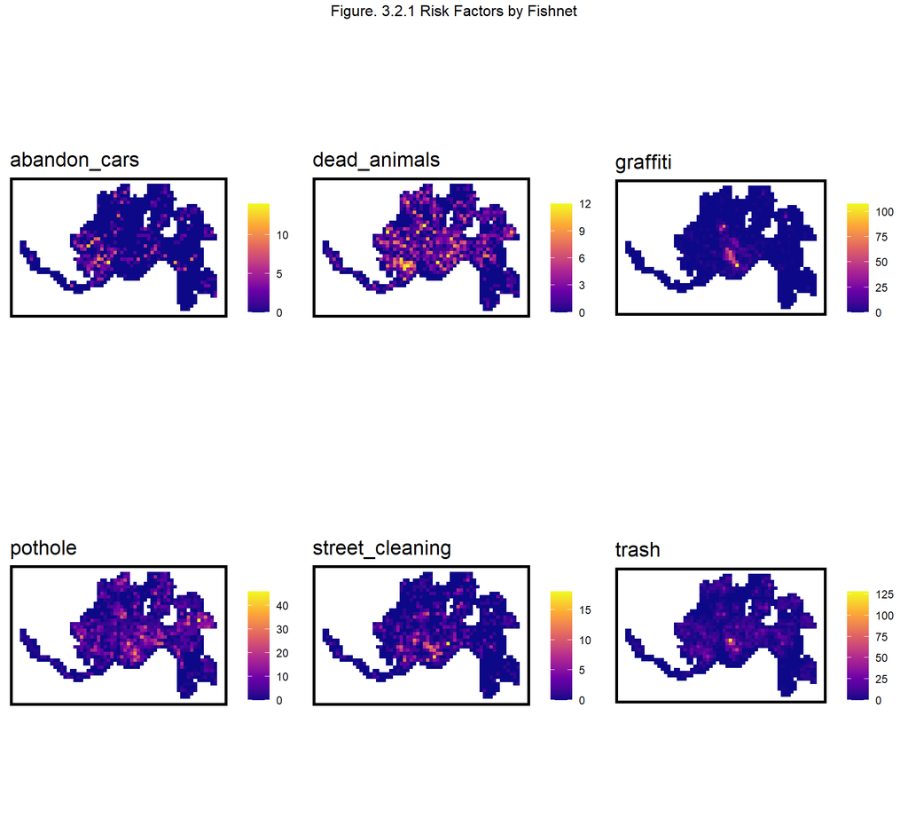

```r
# All variables in fishnet
vars_net <-
  rbind(abandon_cars, dead_animals,pothole,trash,graffiti,street_cleaning) %>%
  st_join(., cin_fishnet, join=st_within) %>%
  st_drop_geometry() %>%
  group_by(uniqueID, Legend) %>%
  summarize(count = n()) %>%
  full_join(cin_fishnet, by = "uniqueID") %>%
  spread(Legend, count, fill=0) %>%
  st_sf() %>%
  na.omit() %>%
  dplyr::select(-`<NA>`) %>%
  ungroup()
### Multiple map for feature counts in fishnet
vars_net.long <-
  gather(vars_net, Variable, value, -geometry, -uniqueID)
vars <- unique(vars_net.long$Variable)
mapList <- list()
for(i in vars){
  mapList[[i]] <-
    ggplot() +
    geom_sf(data = filter(vars_net.long, Variable == i), aes(fill=value), colour=NA) +
    scale_fill_viridis_c(option = "plasma",
                         name = " ") +
    labs(title=i) +
    mapTheme()}
do.call(grid.arrange,c(mapList, ncol =3, top = "Figure. 3.2.1 Risk Factors by Fishnet\n"))
```

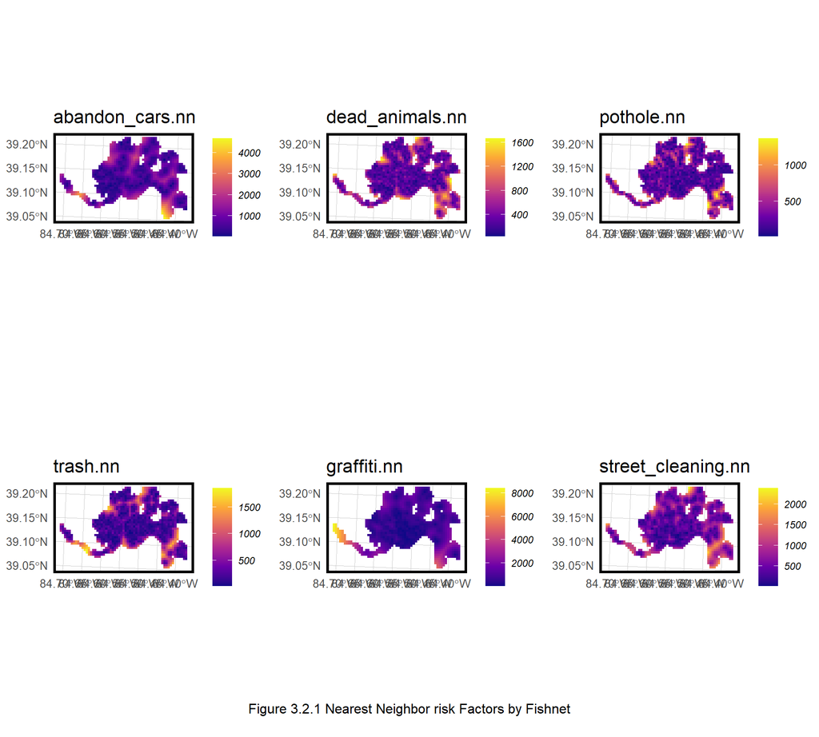

```r
## Nearest Neighbor Feature
# convenience to reduce length of function names.
st_c <- st_coordinates
st_coid <- st_centroid
## create NN from abandoned cars, k = 3
'%!in%' <- function(x,y)!('%in%'(x,y))
vars_net$abandon_cars.nn <-
  nn_function(st_c(st_coid(vars_net)),st_c(abandon_cars),k = 3)

vars_net$dead_animals.nn <-
           nn_function(st_c(st_coid(vars_net)),st_c(dead_animals),k = 3)

vars_net$pothole.nn <-
           nn_function(st_c(st_coid(vars_net)),st_c(pothole),k = 3)

vars_net$trash.nn <-
           nn_function(st_c(st_coid(vars_net)),st_c(trash),k = 3)

vars_net$graffiti.nn <-
           nn_function(st_c(st_coid(vars_net)),st_c(graffiti),k = 3)

vars_net$street_cleaning.nn <-
           nn_function(st_c(st_coid(vars_net)),st_c(street_cleaning),k = 3)
## Visualize the nearest three features
vars_net.long.nn <-
  dplyr::select(vars_net, ends_with(".nn")) %>%
  gather(Variable, value, -geometry)
vars <- unique(vars_net.long.nn$Variable)
mapList <- list()
for(i in vars){
  mapList[[i]] <-
    ggplot() +
    geom_sf(data = filter(vars_net.long.nn, Variable == i), aes(fill=value), colour=NA) +
    scale_fill_viridis_c(option = "plasma",
                         name = " ") +
    labs(title=i) +
    mapTheme() +
    plotTheme()}
do.call(grid.arrange,c(mapList, ncol = 3, bottom = "Figure 3.2.1 Nearest Neighbor risk Factors by Fishnet\n"))
```

```r
# IV and DVs all in fishnet
cin_final_net <-
  left_join(opioid_net, st_drop_geometry(vars_net), by="uniqueID")
cin_final_net <-
  st_centroid(cin_final_net) %>%
  st_join(dplyr::select(cinNeigh, NEIGH), by = "uniqueID") %>%
  st_join(dplyr::select(cinPD, DISTRICT), by = "uniqueID") %>%
  st_drop_geometry() %>%
  left_join(dplyr::select(cin_final_net, geometry, uniqueID)) %>%
  st_sf() %>%
  na.omit()
```